# Project Python Foundations: FoodHub Data Analysis

### Context

The number of restaurants in New York is increasing day by day. Lots of students and busy professionals rely on those restaurants due to their hectic lifestyles. Online food delivery service is a great option for them. It provides them with good food from their favorite restaurants. A food aggregator company FoodHub offers access to multiple restaurants through a single smartphone app.

The app allows the restaurants to receive a direct online order from a customer. The app assigns a delivery person from the company to pick up the order after it is confirmed by the restaurant. The delivery person then uses the map to reach the restaurant and waits for the food package. Once the food package is handed over to the delivery person, he/she confirms the pick-up in the app and travels to the customer's location to deliver the food. The delivery person confirms the drop-off in the app after delivering the food package to the customer. The customer can rate the order in the app. The food aggregator earns money by collecting a fixed margin of the delivery order from the restaurants.

### Objective

The food aggregator company has stored the data of the different orders made by the registered customers in their online portal. They want to analyze the data to get a fair idea about the demand of different restaurants which will help them in enhancing their customer experience. Suppose you are hired as a Data Scientist in this company and the Data Science team has shared some of the key questions that need to be answered. Perform the data analysis to find answers to these questions that will help the company to improve the business.

### Data Description

The data contains the different data related to a food order. The detailed data dictionary is given below.

### Data Dictionary

- order_id: Unique ID of the order
- customer_id: ID of the customer who ordered the food
- restaurant_name: Name of the restaurant
- cuisine_type: Cuisine ordered by the customer
- cost_of_the_order: Cost of the order
- day_of_the_week: Indicates whether the order is placed on a weekday or weekend (The weekday is from Monday to Friday and the weekend is Saturday and Sunday)
- rating: Rating given by the customer out of 5
- food_preparation_time: Time (in minutes) taken by the restaurant to prepare the food. This is calculated by taking the difference between the timestamps of the restaurant's order confirmation and the delivery person's pick-up confirmation.
- delivery_time: Time (in minutes) taken by the delivery person to deliver the food package. This is calculated by taking the difference between the timestamps of the delivery person's pick-up confirmation and drop-off information

### Let us start by importing the required libraries

```python
# Installing the libraries with the specified version.
!pip install numpy==1.25.2 pandas==1.5.3 matplotlib==3.7.1 seaborn==0.13.1 -q --user
```

[output not shown]

**Note**: *After running the above cell, kindly restart the notebook kernel and run all cells sequentially from the start again.*

```python
# import libraries for data manipulation
import numpy as np
import pandas as pd

# import libraries for data visualization
import matplotlib.pyplot as plt
import seaborn as sns
```

### Understanding the structure of the data

```python
from google.colab import drive
drive.mount('/content/drive')
```

```python
# Reading Data into df
df = pd.read_csv("/content/drive/MyDrive/Project Food Hub/foodhub_order.csv")
```

```python
# Returning First five rows of data
df.head()
```

|  | order_id | customer_id | restaurant_name | cuisine_type | cost_of_the_order | day_of_the_week | rating | food_preparation_time | delivery_time |
| --- | --- | --- | --- | --- | --- | --- | --- | --- | --- |
| 0 | 1477147 | 337525 | Hangawi | Korean | 30.75 | Weekend | Not given | 25 | 20 |
| 1 | 1477685 | 358141 | Blue Ribbon Sushi Izakaya | Japanese | 12.08 | Weekend | Not given | 25 | 23 |
| 2 | 1477070 | 66393 | Cafe Habana | Mexican | 12.23 | Weekday | 5 | 23 | 28 |
| 3 | 1477334 | 106968 | Blue Ribbon Fried Chicken | American | 29.20 | Weekend | 3 | 25 | 15 |
| 4 | 1478249 | 76942 | Dirty Bird to Go | American | 11.59 | Weekday | 4 | 25 | 24 |

### **Question 1:** How many rows and columns are present in the data? [0.5 mark]

```python
# Number of rows and columns in data
print("Rows" ,df.shape[0])
print("Columns",df.shape[1])
```

```
Rows 1898
Columns 9
```

#### Observations:

There are 1898 rows and 9 columns in the dataset.

### **Question 2:** What are the datatypes of the different columns in the dataset? (The info() function can be used) [0.5 mark]

```python
# Finding datatypes of different columns
df.info()
```

```
<class 'pandas.core.frame.DataFrame'>
RangeIndex: 1898 entries, 0 to 1897
Data columns (total 9 columns):
 #   Column                 Non-Null Count  Dtype
---  ------                 --------------  -----
 0   order_id               1898 non-null   int64
 1   customer_id            1898 non-null   int64
 2   restaurant_name        1898 non-null   object
 3   cuisine_type           1898 non-null   object
 4   cost_of_the_order      1898 non-null   float64
 5   day_of_the_week        1898 non-null   object
 6   rating                 1898 non-null   object
 7   food_preparation_time  1898 non-null   int64
 8   delivery_time          1898 non-null   int64
dtypes: float64(1), int64(4), object(4)
memory usage: 133.6+ KB
```

## Observations:

There are four columns of type object , four columns of type int and 1 column of type float.There are no missing values .

- INT -order_id ,customer_id ,food_preparation_time,delivery_time.
- Object - restaurant_name,cuisine_type ,day_of_the_week ,rating.
- Float - cost_of_the_order.

### **Question 3:** Are there any missing values in the data? If yes, treat them using an appropriate method. [1 mark]

```python
# checking for missing values
df.isnull().sum()
```

|  | 0 |
| --- | --- |
| order_id | 0 |
| customer_id | 0 |
| restaurant_name | 0 |
| cuisine_type | 0 |
| cost_of_the_order | 0 |
| day_of_the_week | 0 |
| rating | 0 |
| food_preparation_time | 0 |
| delivery_time | 0 |

**dtype:** int64

```python
## Value count for each rating type
df['rating'].value_counts(normalize=True).reset_index()
```

|  | rating | proportion |
| --- | --- | --- |
| 0 | Not given | 0.387777 |
| 1 | 5 | 0.309800 |
| 2 | 4 | 0.203372 |
| 3 | 3 | 0.099052 |

#### Observations:

There are no missing values ,but rating column has 38% of 'Not given' values .Imputing this much data can lead to biased analysis of data.

### **Question 4:** Check the statistical summary of the data. What is the minimum, average, and maximum time it takes for food to be prepared once an order is placed? [2 marks]

```python
# Checking Statistical Summary of the data
df.describe(include='all').T
```

|  | count | unique | top | freq | mean | std | min | 25% | 50% | 75% | max |
| --- | --- | --- | --- | --- | --- | --- | --- | --- | --- | --- | --- |
| order_id | 1898.0 | NaN | NaN | NaN | 1477495.5 | 548.049724 | 1476547.0 | 1477021.25 | 1477495.5 | 1477969.75 | 1478444.0 |
| customer_id | 1898.0 | NaN | NaN | NaN | 171168.478398 | 113698.139743 | 1311.0 | 77787.75 | 128600.0 | 270525.0 | 405334.0 |
| restaurant_name | 1898 | 178 | Shake Shack | 219 | NaN | NaN | NaN | NaN | NaN | NaN | NaN |
| cuisine_type | 1898 | 14 | American | 584 | NaN | NaN | NaN | NaN | NaN | NaN | NaN |
| cost_of_the_order | 1898.0 | NaN | NaN | NaN | 16.498851 | 7.483812 | 4.47 | 12.08 | 14.14 | 22.2975 | 35.41 |
| day_of_the_week | 1898 | 2 | Weekend | 1351 | NaN | NaN | NaN | NaN | NaN | NaN | NaN |
| rating | 1898 | 4 | Not given | 736 | NaN | NaN | NaN | NaN | NaN | NaN | NaN |
| food_preparation_time | 1898.0 | NaN | NaN | NaN | 27.37197 | 4.632481 | 20.0 | 23.0 | 27.0 | 31.0 | 35.0 |
| delivery_time | 1898.0 | NaN | NaN | NaN | 24.161749 | 4.972637 | 15.0 | 20.0 | 25.0 | 28.0 | 33.0 |

#### Observations:

- order_id and customer_id statistics do not make any sense .They are just identifiers.
- There are 178 unique restaurant names in dataset ,most frequently visited  
  is 'Shake Shack'
- There are 14 unique cuisine types ,most favourite is 'American'.
- Average cost of the order is 16.4 ,median is 14.14 . Mean is greater than median slighlty ,it would be slightly right skewed .Min order is 4.47 and maximum is 35.41$.75% of the orders cost were under 22 dollars.
- There are two unique day of the week ('Weekend' and 'Weekday' ) Most orders received are on weekendd.out of 1898 ,1351 orders were on weekends alone.
- Rating column has 4 unique values ('Not given','5','3','4').Most of the rows(736) have 'Not Given'.
- food preparation time - average time to prepare food is 27 minutes ,Median is also 27 ,so data is uniform .Minimum time is 20 minutes and maximun is 35 minutes .75% of the orders were under 31 minutes .
- Delivery Time - average is 24 minutes ,median is 25 so slightly left skewed. Minimum time to deliver is 15 minutes and maximum was 33 minutes .

### **Question 5:** How many orders are not rated? [1 mark]

```python
# Number of orders not rated
df[df['rating']=='Not given'].shape[0]
```

```
736
```

#### Observations:

736 orders out of 1898 orders are not given rating .

### Exploratory Data Analysis (EDA)

### **Question 6:** Explore all the variables and provide observations on their distributions. (Generally, histograms, boxplots, countplots, etc. are used for univariate exploration.) [9 marks]

# Unique values in dataset

```python
## checking for unique in dataframe
df.nunique()
```

|  | 0 |
| --- | --- |
| order_id | 1898 |
| customer_id | 1200 |
| restaurant_name | 178 |
| cuisine_type | 14 |
| cost_of_the_order | 312 |
| day_of_the_week | 2 |
| rating | 4 |
| food_preparation_time | 16 |
| delivery_time | 19 |

**dtype:** int64

## Observations:

There are 178 unique restaurants, 14 unique cusinines , 1200 unique customers 2 unique days of week and 4 unique ratings.

# Customer ID

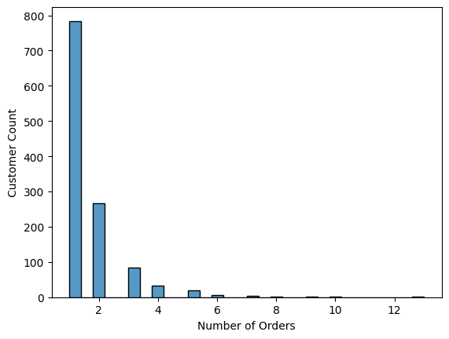

```python
### Number of orders for customers
orders_per_customer = df['customer_id'].value_counts().reset_index()
orders_per_customer.columns = ['customer_id', 'Number of Orders']
sns.histplot(data=orders_per_customer,x='Number of Orders', bins=30);
plt.xlabel('Number of Orders');
plt.ylabel('Customer Count');
plt.show()
```

### Observations:

Most of the customers have just placed 1 order.Less of Repeat Customers.

# Restaurant Name

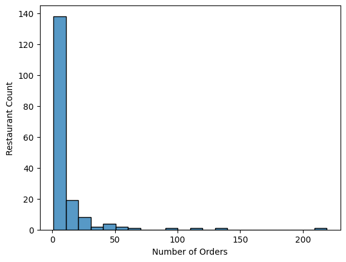

```python
## ### Number of orders for restaurants
orders_per_rest = df['restaurant_name'].value_counts().reset_index()
orders_per_rest.columns = ['restaurant_name', 'Number of Orders']
sns.histplot(data=orders_per_rest,x='Number of Orders',binwidth=10, bins=100);
plt.xlabel('Number of Orders');
plt.ylabel('Restaurant Count');
plt.show()
```

### Observation:

There are 178 unique restaurants but most restaurants have received less than 10 orders.

# Cost of the order

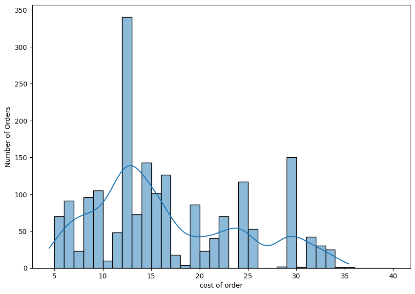

```python
## Cost of order Histogram
plt.figure(figsize=(10,7))
sns.histplot(data=df,x='cost_of_the_order',binwidth=1,binrange=(5,40),kde=True)
plt.xlabel('cost of order')
plt.ylabel('Number of Orders')
plt.show()
```

```python
## Percentage of orders in range of 5 to 20 dollars
(df[(df['cost_of_the_order']>5) & (df['cost_of_the_order']<20) ].shape[0]/df.shape[0])*100
```

```
70.2845100105374
```

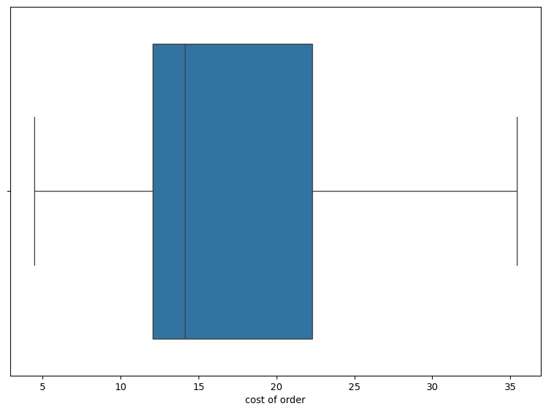

```python
## Cost of order Boxplot
plt.figure(figsize=(10,7))
sns.boxplot(data=df,x='cost_of_the_order')
plt.xlabel('cost of order')
plt.show()
```

### Observations:

1. Histogram and box plot for cost of order shows ,data is slightly right skewed .
2. It has highest peak in order range of 12-14 dollars and some small peaks at 24-25 and 29-30 dollars.
3. 70% of the order cost was in between 5 to 20 dollars.
4. No Outliers present.

# Food Preparation Time

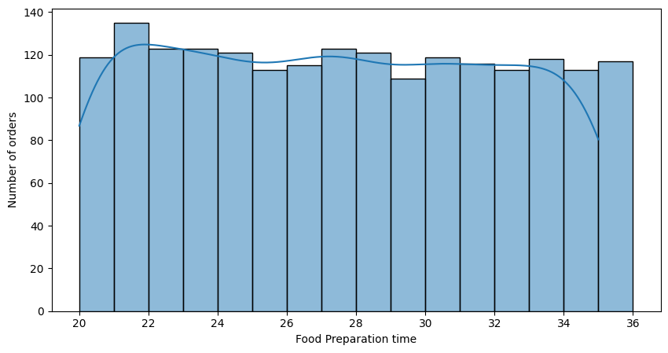

```python
## Food Preparation time Histogram
plt.figure(figsize=(10,5))
sns.histplot(data=df,x='food_preparation_time',binwidth=1,binrange=(20,36),kde=True)
plt.xlabel('Food Preparation time')
plt.ylabel('Number of orders')
plt.show()
```

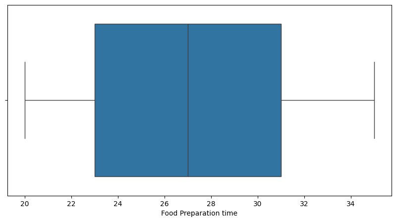

```python
## Food Preparation time boxplot
plt.figure(figsize=(10,5))
sns.boxplot(data=df,x='food_preparation_time')
plt.xlabel('Food Preparation time')
plt.show()
```

### Observations:

1. Food preparation time seems to be uniform across all orders,with slightly more orders prepared in range of 21-22 minutes
2. Average time to prepare food is 27 minutes ,Median is also 27 ,so data is uniform
3. Minimum time is 20 minutes and maximum is 35 minutes.
4. 75% of the orders were prepared under 31 minutes.
5. There are no outliers in the data.

# Delivery Time

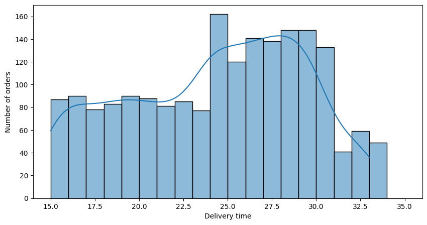

```python
## Delivery time histplot
plt.figure(figsize=(10,5))
sns.histplot(data=df,x='delivery_time',binwidth=1,binrange=(15,35),kde=True)
plt.xlabel('Delivery time')
plt.ylabel('Number of orders')
plt.show()
```

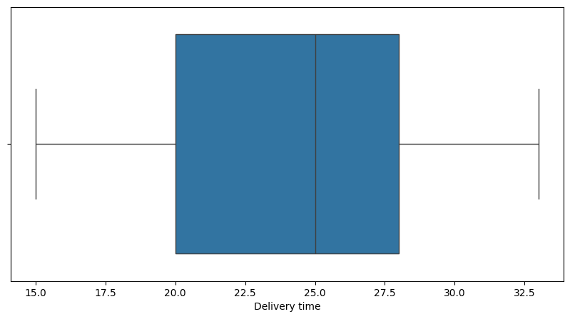

```python
## Delivery Time Boxplot
plt.figure(figsize=(10,5))
sns.boxplot(data=df,x='delivery_time')
plt.xlabel('Delivery time')
plt.show()
```

### Observations:

1. Data is slightly left skewed with more orders in delivery time of 24-30 minutes.
2. Average is 24 minutes ,Minimum time to deliver is 15 minutes and maximum was 33 minutes.
3. 75% of orders being delivered under 28 minutes.
4. Delivery time is spread from 15 to 33 minutes.
5. No outliers present.

# Rating

```python
## Unique Rating
df['rating'].unique()
```

```
array(['Not given', '5', '3', '4'], dtype=object)
```

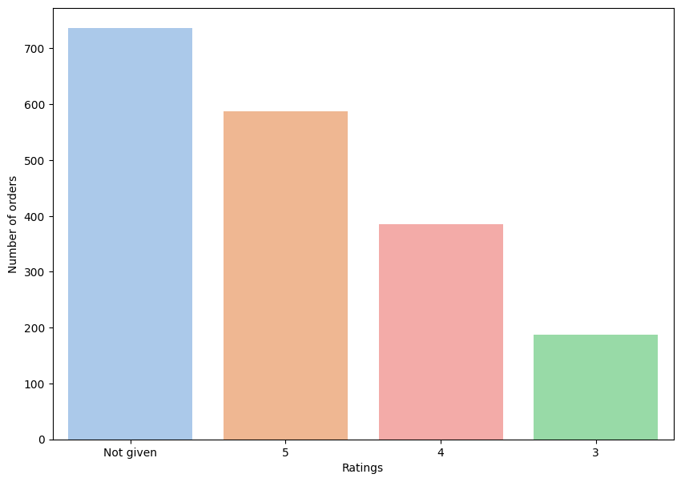

```python
## Rating Category countplot
plt.figure(figsize=(10,7))
sns.countplot(data=df, x='rating', hue='rating', order=df['rating'].value_counts().index, palette='pastel', legend=False)
plt.xlabel('Ratings')
plt.ylabel('Number of orders')
plt.show()
```

## Observations:

736 orders were not rated .while most of the orders were rated between 4 and 5.

1. There are 4 unique ratings ('Not given','5,'4','3').
2. 736 orders have not been rated .
3. Most of the orders received rating 4-5.

# Cuisine Type

```python
## Top 5 Cuisines and their total cost of order
group_df = df.groupby(['cuisine_type'])['cost_of_the_order'].sum().sort_values(ascending=False).reset_index()
group_df.head(5)
```

|  | cuisine_type | cost_of_the_order |
| --- | --- | --- |
| 0 | American | 9530.78 |
| 1 | Japanese | 7663.13 |
| 2 | Italian | 4892.77 |
| 3 | Chinese | 3505.62 |
| 4 | Mexican | 1303.85 |

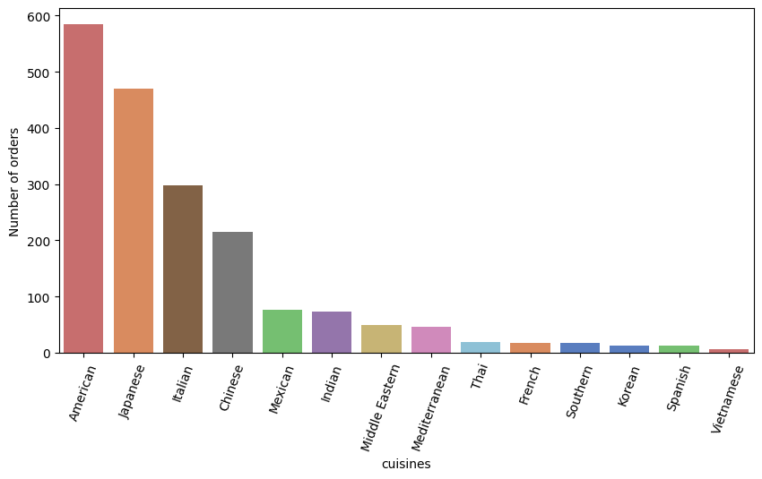

```python
## cuisine type countplot
plt.figure(figsize=(10,5))
sns.countplot(data=df, x='cuisine_type',hue='cuisine_type',  order=df['cuisine_type'].value_counts().index, palette='muted', legend=False)
plt.xlabel('cuisines')
plt.ylabel('Number of orders')
plt.xticks(rotation=70)
plt.show()
```

```python
## Revenue from top 5 cuisine types
top_cuisines = ['American','Japanese','Italian','Chinese','Mexican']
total_cost = df[df['cuisine_type'].isin(top_cuisines)]['cost_of_the_order'].sum()
((total_cost)/(df['cost_of_the_order'].sum()))*100
```

```
85.88952451267483
```

## Observations:

1. American ,Japanese,Italian,Chinese,Mexican are the most ordered cuisine types.
2. Revenue from these top five cuisines alone is 86%
3. Korean,spanish and Vietnamese are least ordered.

# Day of the Week

```python
## Unique Day of Week
df['day_of_the_week'].unique()
```

```
array(['Weekend', 'Weekday'], dtype=object)
```

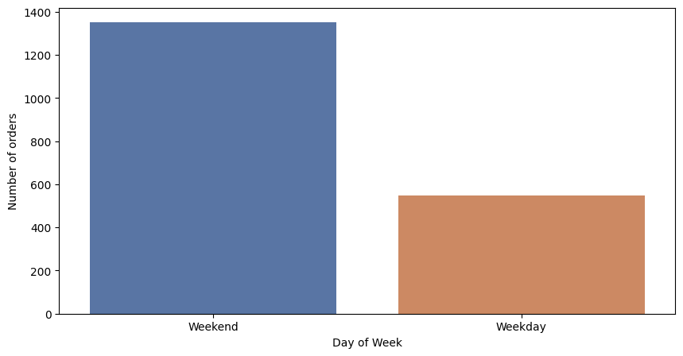

```python
## Day of the week Countplot
plt.figure(figsize=(10,5))
sns.countplot(data=df,x='day_of_the_week', hue='day_of_the_week',palette='deep', legend=False)
plt.xlabel('Day of Week')
plt.ylabel('Number of orders')

plt.show()
```

```python
## Orders placed on Days of Week
df['day_of_the_week'].value_counts().reset_index()
```

|  | day_of_the_week | count |
| --- | --- | --- |
| 0 | Weekend | 1351 |
| 1 | Weekday | 547 |

```python
## Percentage of orders placed on Weekend
(df[df['day_of_the_week']=='Weekend'].shape[0]/df.shape[0])*100
```

```
71.18018967334035
```

### Observations:

1. There are two unique days of week - 'Weekday' and 'Weekend'.
2. Most orders were placed on Weekends than on Weekdays.
3. Weekend - 1351 orders 71% of total orders.
4. Weekday - 547 orders 28% of total orders.

# Top 10 Restaurants and their total cost of order.

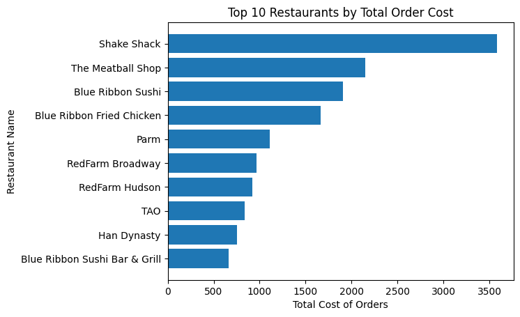

```python
group_df = df.groupby(['restaurant_name'])['cost_of_the_order'].sum().sort_values(ascending=False).reset_index()
top_10_restaurants = group_df.head(10)
plt.barh(top_10_restaurants['restaurant_name'], top_10_restaurants['cost_of_the_order'])
plt.xlabel('Total Cost of Orders')
plt.ylabel('Restaurant Name')
plt.title('Top 10 Restaurants by Total Order Cost')

plt.gca().invert_yaxis()
plt.show()
```

### **Question 7**: Which are the top 5 restaurants in terms of the number of orders received? [1 mark]

```python
# Top 5 Restaurants
df['restaurant_name'].value_counts().head().reset_index()
```

|  | restaurant_name | count |
| --- | --- | --- |
| 0 | Shake Shack | 219 |
| 1 | The Meatball Shop | 132 |
| 2 | Blue Ribbon Sushi | 119 |
| 3 | Blue Ribbon Fried Chicken | 96 |
| 4 | Parm | 68 |

#### Observations:

Top 5 Restaurants in order of orders received are:

1. Shake Shack -219
2. The Meatball Shop -132
3. Blue Ribbon Sushi - 119
4. Blue Ribbon Fried Chicken - 96
5. Parm - 68

### **Question 8**: Which is the most popular cuisine on weekends? [1 mark]

```python
# Most Popular Cuisine on Weekends
df_cuisine_weekend = df[df['day_of_the_week']=='Weekend']
df_cuisine_weekend['cuisine_type'].value_counts().head().reset_index()
```

|  | cuisine_type | count |
| --- | --- | --- |
| 0 | American | 415 |
| 1 | Japanese | 335 |
| 2 | Italian | 207 |
| 3 | Chinese | 163 |
| 4 | Mexican | 53 |

#### Observations:

American is the most popular cuisine type on weekends followed by japanese and Italian.

### **Question 9**: What percentage of the orders cost more than 20 dollars? [2 marks]

```python
# Write the code here
df_orders_more_than_20 = df[df['cost_of_the_order']>20]
print("percenatge of orders which cost more than 20 dollars is",round((df_orders_more_than_20.shape[0]/df.shape[0])*100,2),"%")
```

```
percenatge of orders which cost more than 20 dollars is 29.24 %
```

#### Observations:

29.24% of the total orders cost more than 20 dollars.That means 70% of the orders are below 20 dollars .

### **Question 10**: What is the mean order delivery time? [1 mark]

```python
# Write the code here
print("Mean order delivery time is ",round(df['delivery_time'].mean(),2),"minutes")
```

```
Mean order delivery time is  24.16 minutes
```

#### Observations:

Average delivery time of all orders is 24.16 minutes

### **Question 11:** The company has decided to give 20% discount vouchers to the top 3 most frequent customers. Find the IDs of these customers and the number of orders they placed. [1 mark]

```python
top_3_customers = df.groupby(['customer_id'])['order_id'].count().sort_values(ascending=False).reset_index()
top_3_customers.head(3)
```

|  | customer_id | order_id |
| --- | --- | --- |
| 0 | 52832 | 13 |
| 1 | 47440 | 10 |
| 2 | 83287 | 9 |

#### Observations:

Top 3 frequent customers are:

1. ID no 52832 placed 13 orders
2. ID no 47440 placed 10 orders
3. ID no 83287 placed 9 orders

### **Question 12**: Perform a multivariate analysis to explore relationships between the important variables in the dataset. (It is a good idea to explore relations between numerical variables as well as relations between numerical and categorical variables) [10 marks]

# Cuisines and their Cost of Order

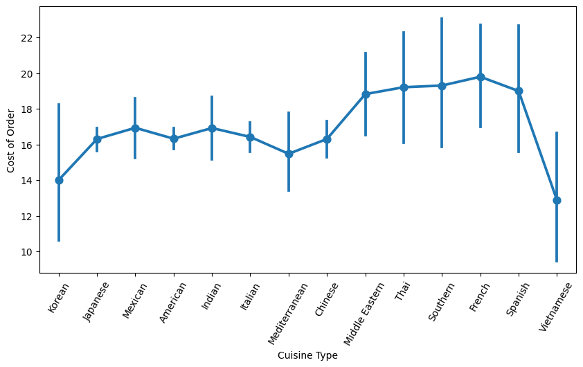

```python
# pointplot for cuisines and their cost of order
plt.figure(figsize=(10,5))
sns.pointplot(data=df,x='cuisine_type',y='cost_of_the_order')
plt.xlabel('Cuisine Type')
plt.ylabel('Cost of Order')
plt.xticks(rotation=60)
plt.show()
```

### Observations:

1. Average Cost of order for the most frequently ordered cusines American,Japanese,Chinese ,Italian is almost same .
2. Cost of order for Middle Eastern,Thai,Southern ,French is high
3. French is the most expensive while Vietnamese is least expensive

## Cuisines and their food preparation Time.

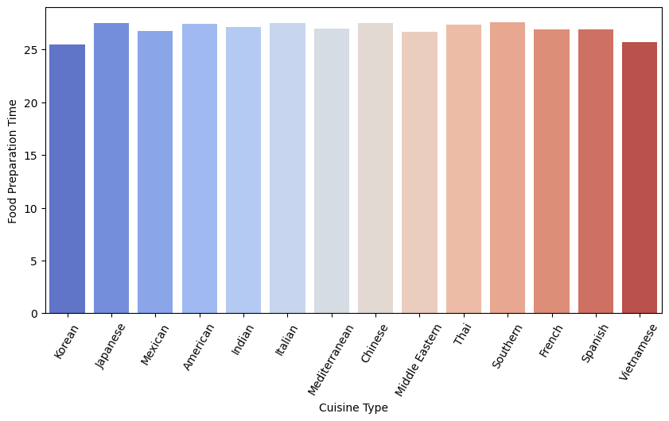

```python
## Various Cuisines and their food preparation time .
plt.figure(figsize=(10,5))
sns.barplot(data=df,x='cuisine_type',y='food_preparation_time',palette='coolwarm',hue='cuisine_type',errorbar=('ci', False))
plt.xlabel('Cuisine Type')
plt.ylabel('Food Preparation Time')
plt.xticks(rotation=60)
plt.show()
```

### Observations:

1. Food Preparation time is uniform across all cuisines.
2. Japanese ,American and Italian takes slightly more to prepare.
3. Korean and Vietnamese takes lesser time than all.

## Cuisines and their delivery time

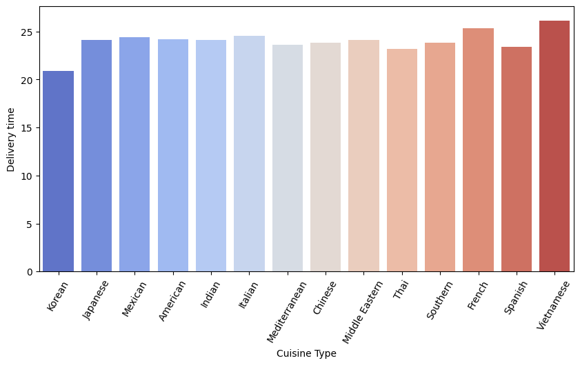

```python
## Various Cuisines and their delivery time .
plt.figure(figsize=(10,5))
sns.barplot(data=df,x='cuisine_type',y='delivery_time',palette='coolwarm',hue='cuisine_type',errorbar=('ci', False))
plt.xlabel('Cuisine Type')
plt.ylabel('Delivery time')
plt.xticks(rotation=60)
plt.show()
```

### Observations:

1. It takes almost same time to deliver top 5 cuisines ,American ,Japanese,Chinese,Italian ,Mexican.
2. But it takes very less time to deliver Korean food may be because their food preparation time is less.
3. And Vietnamese food takes longer to deliver .may be their location is in outskirts

## Cuisines and their ratings.

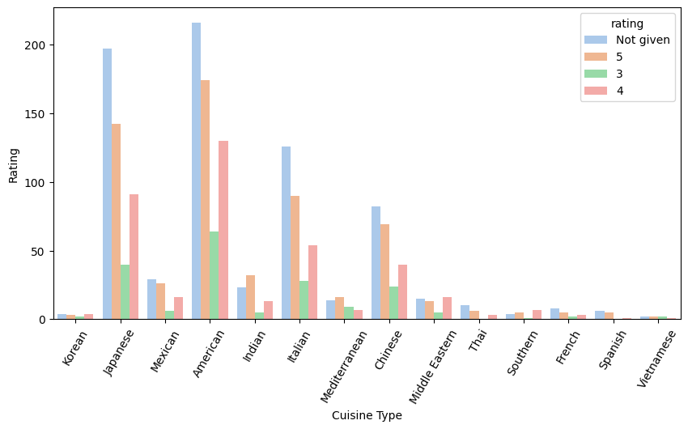

```python
## Cuisine Types and their rating.
plt.figure(figsize=(10,5))
sns.countplot(data=df,x='cuisine_type',hue='rating',palette='pastel')
plt.xlabel('Cuisine Type')
plt.ylabel('Rating')
plt.xticks(rotation=60)
plt.show()
```

### Observations:

American ,Japanese ,Italian and Chinese have been given the most 5 an 4 ratings and also not rated more than other restaurants.

## Cost of order on Day of week

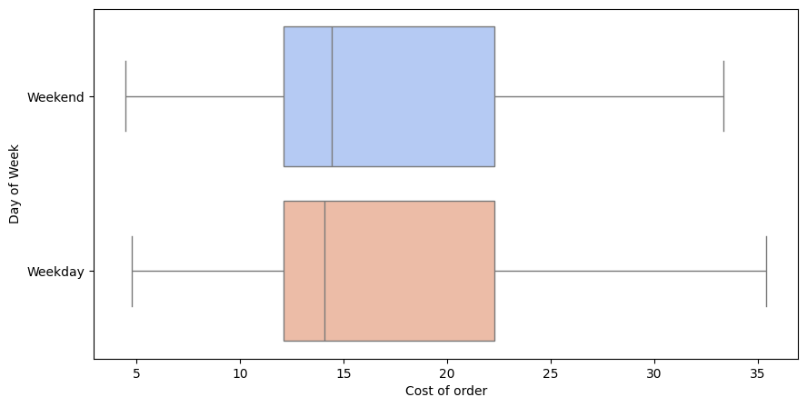

```python
## Cost of order on weekend and weekdays
plt.figure(figsize=(10,5))
sns.boxplot(data=df,x='cost_of_the_order',y='day_of_the_week',palette='coolwarm',hue='day_of_the_week')
plt.xlabel('Cost of order')
plt.ylabel('Day of Week')
plt.show()
```

## Observations:

Cost of order is slightly more on weekends than on weekdays.

## Food preparation time on day of week

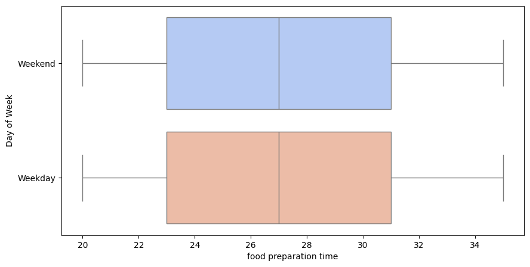

```python
## Food preparation time on day of the week.
plt.figure(figsize=(10,5))
sns.boxplot(data=df,x='food_preparation_time',y='day_of_the_week',palette='coolwarm',hue='day_of_the_week')
plt.xlabel('food preparation time')
plt.ylabel('Day of Week')
plt.show()
```

## Observations:

Food preparation time is similar on weekday and weekends.

## Delivery time on day of week

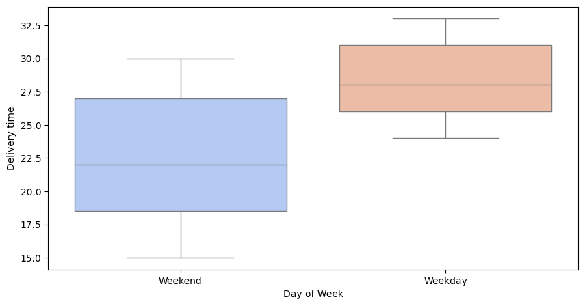

```python
## Delivery time on day of week
plt.figure(figsize=(10,5))
sns.boxplot(data=df,x='day_of_the_week',y='delivery_time',palette='coolwarm',hue='day_of_the_week')
plt.xlabel('Day of Week')
plt.ylabel('Delivery time')
plt.show()
```

### Observations:

- Median delivery time on the weekend is lower than the median delivery time of weekdays.
- Delivery time on weekend varies from 15 mins to 30 minutes but on weekday it varies from approx 25 mins to 33 mins. on weekends delivery time has higher spread than weekdays.

## Food preparation time for various cusines on day of week

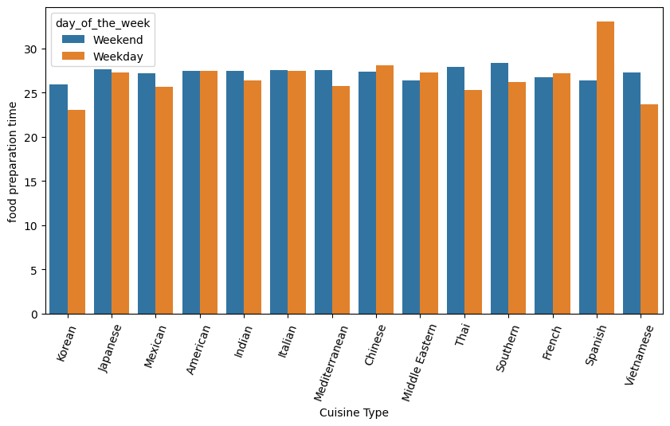

```python
## Food preparation time for  various cusines on day of week
plt.figure(figsize=(10,5))
sns.barplot(data=df,x='cuisine_type',y='food_preparation_time',hue='day_of_the_week',errorbar=('ci',False))
plt.xlabel("Cuisine Type")
plt.ylabel("food preparation time")
plt.xticks(rotation=70)
plt.show()
```

## Cost of order for cuisines on day of week

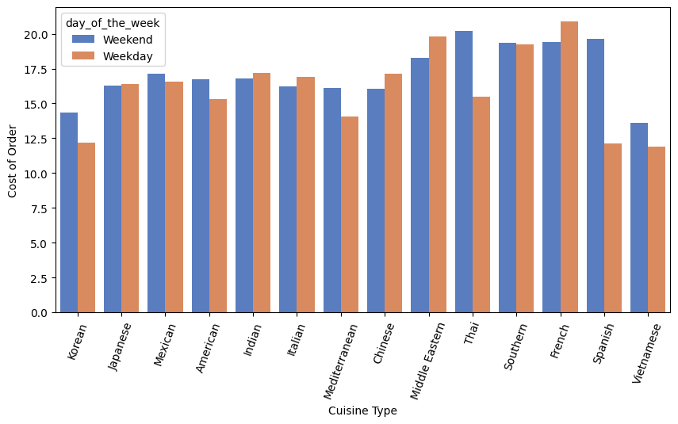

```python
## Cost of order for cuisines on day of week
plt.figure(figsize=(10,5))
sns.barplot(data=df,x='cuisine_type',y='cost_of_the_order',hue='day_of_the_week',errorbar=('ci',False),palette='muted')
plt.xlabel('Cuisine Type')
plt.ylabel('Cost of Order')
plt.xticks(rotation=70)
plt.show()
```

## Rating and cost of order

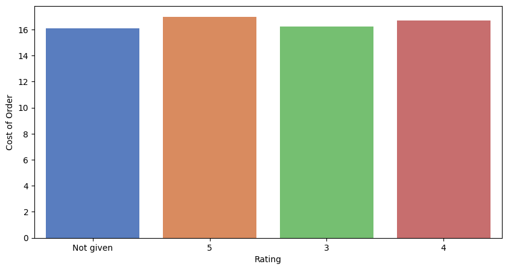

```python
## Rating and cost of order
plt.figure(figsize=(10,5))
sns.barplot(data=df,x='rating',y='cost_of_the_order',errorbar=('ci',False),palette='muted',hue='rating')
plt.xlabel('Rating')
plt.ylabel('Cost of Order')
plt.show()
```

## Observations:

Rating 5 and 4 has been given for the food order which costs more .

## Rating and delivery time

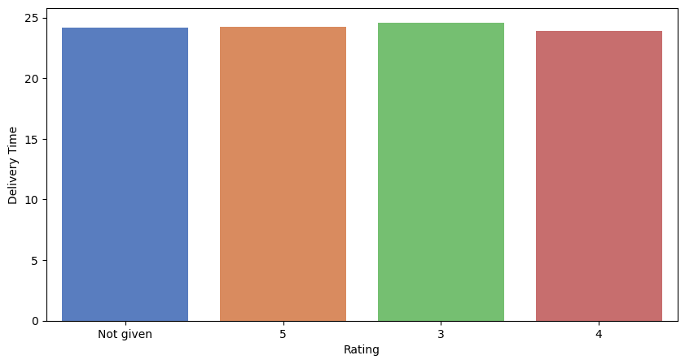

```python
## Rating and delivery time
plt.figure(figsize=(10,5))
sns.barplot(data=df,x='rating',y='delivery_time',errorbar=('ci',False),palette='muted',hue='rating')
plt.xlabel('Rating')
plt.ylabel('Delivery Time')
plt.show()
```

### Observations:

5,4 and 'Not given' ratings were for when delivery time is less but more 3 is given for the orders with large delivery time.

## Rating and food preparation time

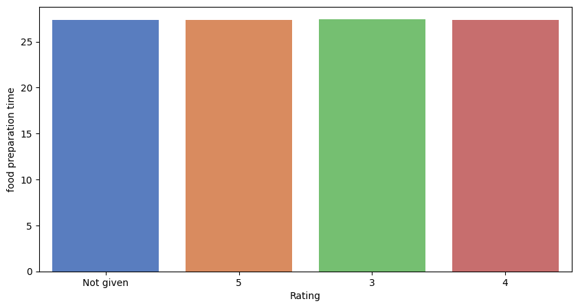

```python
## Rating and food preparation time
plt.figure(figsize=(10,5))
sns.barplot(data=df,x='rating',y='food_preparation_time',errorbar=('ci',False),palette='muted',hue='rating')
plt.xlabel('Rating')
plt.ylabel('food preparation time')
plt.show()
```

## Observations:

Rating doesn't show much difference with food preparation time.

## Correlation

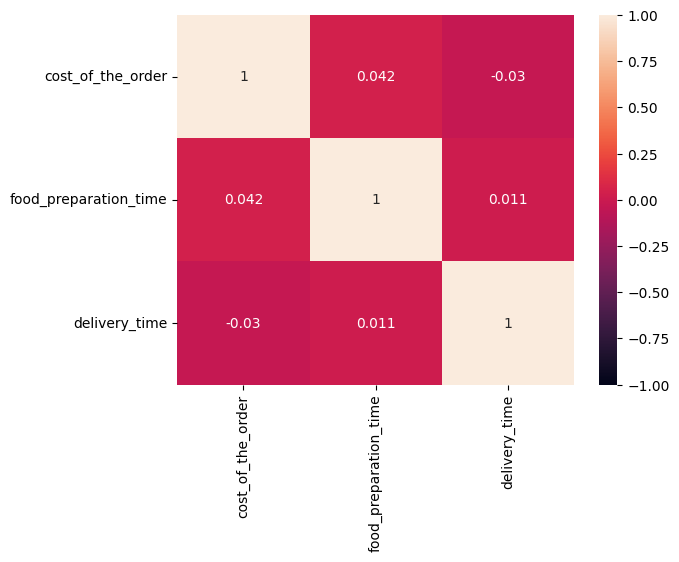

```python
## Correlation matrix
dt = ['cost_of_the_order','food_preparation_time','delivery_time']
sns.heatmap(df[dt].corr(),annot=True,vmin=-1,vmax=1)
plt.show()
```

### Observations:

No significant correlation exists between numerical values.

```python
df.groupby('cuisine_type')['restaurant_name'].nunique().sort_values(ascending=False).reset_index()
```

|  | cuisine_type | restaurant_name |
| --- | --- | --- |
| 0 | American | 41 |
| 1 | Italian | 31 |
| 2 | Japanese | 29 |
| 3 | Chinese | 16 |
| 4 | Indian | 14 |
| 5 | Mexican | 11 |
| 6 | Thai | 9 |
| 7 | Middle Eastern | 7 |
| 8 | Korean | 5 |
| 9 | Mediterranean | 5 |
| 10 | French | 3 |
| 11 | Spanish | 3 |
| 12 | Vietnamese | 3 |
| 13 | Southern | 2 |

### Observations:

May be American and Japanese are best selling because there are more restaurants selling these cuisines.

### **Question 13:** The company wants to provide a promotional offer in the advertisement of the restaurants. The condition to get the offer is that the restaurants must have a rating count of more than 50 and the average rating should be greater than 4. Find the restaurants fulfilling the criteria to get the promotional offer. [3 marks]

```python
# Write the code here
# dataframe without 'Not given' for rating column
df1 = df.loc[df['rating']!='Not given'].copy()

# changed datatype of rating to int
df1['rating']=df1['rating'].astype('int')

# Grouped by restaurant name
df1_grouped = df1.groupby('restaurant_name')

#applying count and mean on rating
df1_rated = df1_grouped['rating'].agg(['count','mean'])

# filtering restaurants with rating count > 50 and mean rating >4
df1_filtered = df1_rated[(df1_rated['count']>50) & (df1_rated['mean']>4)]

# sorting by rating count
df1_filtered_sorted = df1_filtered.sort_values(by='count',ascending=False)

# reset index
df1_filtered_sorted = df1_filtered_sorted.reset_index()

# renaming column names to Rating count and Average Rating
df1_filtered_sorted = df1_filtered_sorted.rename(columns={'count':'Rating Count','mean':'Average Rating'})

print(df1_filtered_sorted)
```

```
             restaurant_name  Rating Count  Average Rating
0                Shake Shack           133        4.278195
1          The Meatball Shop            84        4.511905
2          Blue Ribbon Sushi            73        4.219178
3  Blue Ribbon Fried Chicken            64        4.328125
```

#### Observations:

Restaurants having rating count more than 50 and average rating more than 4 are:

1. Shake Shack
2. The Meatball Shop
3. Blue Ribbon Sushi
4. Blue Ribbon Fried Chicken

### **Question 14:** The company charges the restaurant 25% on the orders having cost greater than 20 dollars and 15% on the orders having cost greater than 5 dollars. Find the net revenue generated by the company across all orders. [3 marks]

```python
# function to calculate revenue
def comp_revenue(cost):
  if cost >20:
    return 0.25*cost
  elif cost>5:
    return 0.15*cost
  else:
    return 0

df['revenue'] = df['cost_of_the_order'].apply(comp_revenue)

# Total revenue for company
total_revenue = df['revenue'].sum()

print('Net revenue for company across all orders is ', round(total_revenue,2),'dollars')
```

```
Net revenue for company across all orders is  6166.3 dollars
```

#### Observations:

Net Revenue generated by company across all orders :6166.3 dollars

### **Question 15:** The company wants to analyze the total time required to deliver the food. What percentage of orders take more than 60 minutes to get delivered from the time the order is placed? (The food has to be prepared and then delivered.) [2 marks]

```python
# Calculating Total time for each order
df['total_time_to_deliver'] = df['food_preparation_time']+df['delivery_time']

# Total orders taking more than 60 minutes
df.loc[df['total_time_to_deliver']>60].shape[0]

# Percentage of orders taking more than 60 minutes
Percentage_of_orders = (df.loc[df['total_time_to_deliver']>60].shape[0]/df.shape[0])*100

print("Percentage of orders taking more than 60 minutes is ",round(Percentage_of_orders,2),'%')
```

```
Percentage of orders taking more than 60 minutes is  10.54 %
```

#### Observations:

10.54% of total orders takes more than 60 minutes to deliver.

### **Question 16:** The company wants to analyze the delivery time of the orders on weekdays and weekends. How does the mean delivery time vary during weekdays and weekends? [2 marks]

```python
# Write the code here
# mean delivery time during weekends
Weekend_mean = df[df['day_of_the_week']=='Weekend']['delivery_time'].mean()
Weekday_mean = df[df['day_of_the_week']=='Weekday']['delivery_time'].mean()

print('Mean delivery time on weekend is',round(Weekend_mean,2),'minutes')
print('Mean delivery time on weekday is',round(Weekday_mean,2),'minutes')
```

```
Mean delivery time on weekend is 22.47 minutes
Mean delivery time on weekday is 28.34 minutes
```

#### Observations:

Mean delivery time on weekend is 22.47 minutes ,while mean delivery time on weekday is 28.34 minutes . Which we saw in the graph as well.

### Conclusion and Recommendations

### **Question 17:** What are your conclusions from the analysis? What recommendations would you like to share to help improve the business? (You can use cuisine type and feedback ratings to drive your business recommendations.) [6 marks]

### Conclusions:

- Very small number of Customers order multiple times from Food Hub.
- approximately 38% of orders are not rated.
- Average Delivery time is higher on weekday as compared to weekend.
- Cost for most of the orders are between 10-20 Dollars.May be because there are more students or bachelors who order.
- There are very few restaurants who has more than 25 orders.
- American cuisine is the most popular cuisine.
- Customers order more on weekend than weekday.
- Top five restaurants in terms of order count have more than 33% of orders

### Recommendations:

- Foodhub should offer a discount to repetitive customer such as a loyalty membership and reward points to increase the percentage of order from repeat customer.
- Provide incentives for weekend orders since delievery time is less hence more orders can be delievered.
- Increase manpower on weekdays to improve delievery time. Manpower can reduced on weekends.
- Customer should be encouraged to provide rating for their order it will help understanding correlations better between different parameters including but not limited to restaurant performance, cost of the order, food delivery time.
- Explore contibuting factors causing slower delieveries on weekdays and work on improvising the same. Also collect data on more granual level so exact order times are also available. Order time would help in analysing peak hours of weekdays so customers can be notified about delay beforehand which increases customer experience overall.
- Get the demographic details about users to better analyse demands.

```python
!jupyter nbconvert --to html '/content/drive/MyDrive/Project Food Hub/Learner_Notebook_Full_Code.ipynb'
```

```
[NbConvertApp] Converting notebook /content/drive/MyDrive/Project Food Hub/Learner_Notebook_Full_Code.ipynb to html
[NbConvertApp] Writing 1632457 bytes to /content/drive/MyDrive/Project Food Hub/Learner_Notebook_Full_Code.html
```